# Intro-Machine-Learning-R

# 1 Goal

1. Become familiar with the basic predictive machine learning landscape
2. Appropriately preprocess the UCI heart disease dataset
3. Fit single model to train/test sets and evaluate performance
4. Deploy a cross-validated ensemble of multiple algorithms for simultaneous comparison

# 2 Introduction: What is machine learning?

Machine learning (or statistical learning) is a combination of statistics and computer science that is often defined as an algorithm or a computer program that can learn on its own, as it is given more data and without human input. It can be thought of as a toolbox for exploring and modeling data with applications in scientific research, such as in making predictions or inferences, or exploring the structure of a dataset.

Machine learning can be defined as:

> “a vast set of tools for *understanding data*. These tools can be classified as supervised or unsupervised. Broadly speaking, supervised statistical learning involves building a statistical model for predicting, or estimating, an output based on one or more inputs… With unsupervised statistical learning, there are inputs but no supervising output; nevertheless we can learn relationships and structure from such data.” (James et al. 2021, p. 1).

[James G, Witten D, Hastie T, Tibshirani R. 2021. An Introduction to Statistical Learning: With Applications in R, 2nd edition.](https://www.statlearning.com)

> NOTE: there are other approaches as well, such as: semi-supervised, deep, reinforcement, and targeted/causal.

## 2.1 Machine learning terminology

First, it’s important to become familiar with the basic vocabulary of relevant terms, to understand how the different parts work independently and together.

The focus of this workflow is on **supervised learning** for a **classification task** using the [SuperLearner R package](https://cran.r-project.org/web/packages/SuperLearner/index.html). We will follow the [Guide to SuperLearner](https://cran.r-project.org/web/packages/SuperLearner/vignettes/Guide-to-SuperLearner.html).

1. **Supervised learning:** is a predictive technique that trains a model on known, labeled data. The goal is to understand the relationships between variables in a dataset so that the trained model can be used to make predictions on new data it has not yet seen, and whose labels are unknown. Or, as James et al. (2021, p. 26) state:

> “We wish to fit a model that relates the response to the predictors, with the aim of accurately predicting the response for future observations (prediction) or better understanding the relationship between the response and the predictors (inference).”
- **Classification:** is the supervised task when the Y variable is discrete/categorical ($Pr(y=1|x)$). For binary classification, 1 is the “yes”, or positive class. 0 is the “no”, or negative class. This can also extend to multiclass problems as well.
- **Regression:** is the supervised task when the Y variable is continuous (i.e., numeric or integer) ($E(y|x)$)
2. **Supervised syntax**

$Y ~ X1 + X2 + X3 ... + Xn$

Simply put, we want to use the X variables to predict Y.

3. **X and Y variables:**
- **X** is/are the independent variable(s) that we use to do the predicting. These are also referred to as features, covariates, predictors, and explanatory/input variables.
- **Y** is the dependent variable and the one we want to predict. It is also referred to as the outcome, target, or response variable. Although predicting the label itself might be convenient, predicting the class probabilities is more efficient.
- A machine learning function might look like this:

$y=f(x)+ϵ$

where f is the function to estimate the relationships between **X** to **Y**. The random error epsilon ϵ is independent of x and averages to zero. We can therefore use $y=f(x)$ to predict **Y** for new data (the test dataset) and evaluate how well the algorithm learned the target function when trained and then introduced to the new data.

4. **Data splitting:** Predictions are usually evaluated twice:
5. First, on the labeled training set, to see how well the model can learn the relationships between the **X** and **Y** variables, and then
6. Then on the test set, to see how well the trained model can generalize to predicting on new data.

To accomplish this task, a given dataset is subdivided into training and test sets.

- The **training set:** generally consists of the majority portion of the original dataset (70%, for example) where the model can learn the relationships between the **X** and **Y** variables.
  - **Hyperparameters:** are the configurations manually set by the programmer prior to model training through heuristics and trial and error, or a grid search. We do not know the optimal combinations of these options, and must tune the hyperparameters through the model training process to optimize prediction performance.
- The **test set:** consists of the remaining portion of the dataset (30% in this example) that the trained model will then try to predict without seeing the Y labels.

> NOTE: A validation set is also sometimes used for hyperparameter tuning/model selection on the training dataset and are to be learned. While the parameters represent the internal configuration of the model, hyperparameters are defined by the user before training begins.
- **k-fold cross-validation:** is a preferred method for approaching the data splitting process because it repeats the train/test split process “k” number of times and rotates portions of the dataset to ensure that each observation is in the test set at least once.

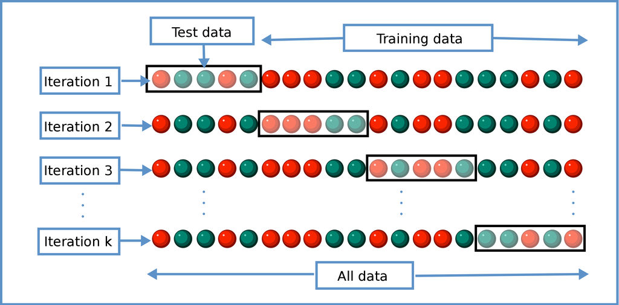

https://en.wikipedia.org/wiki/Cross-validation_(statistics)

5. **Performance metrics:** It is necessary to evaluate model performance on the training and test sets (and validation set, when applicable) through a variety of [confusion matrix derivations](https://en.wikipedia.org/wiki/Confusion_matrix).

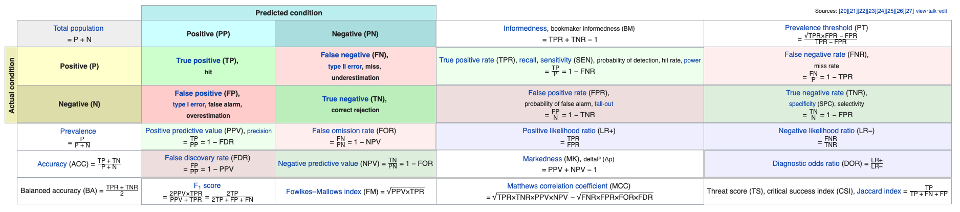

https://en.wikipedia.org/wiki/Confusion_matrix

> Keep in mind that misclassification error is often an inappropriate performance metric, particularly when dealing with a **Y** variable whose distribution is imbalanced.
- A model is **underfit** if it cannot learn the relationships between the **X** and **Y** variables on the training set.
- A model is **overfit** if it adequately learns the relationships between the **X** and **Y** variables and performs well on the training set, but performs poorly on the test set.

## 2.2 Example machine learning workflow:

1. Read literature in your field to understand what has been done; annotate what you read
2. Formulate research question(s)
3. Obtain data
4. Preprocess data (often the most time-consuming part of ML workflows!)
- scale variables when necessary
- handle missing values if present (listwise delete, median impute, multiple impute, generalized low rank model impute, etc.)
- if present, convert factor variables to numeric indicators
5. Define x and y variables
6. Split data into train and test sets
7. Train and evaluate performance of a single algorithm as a prototype
8. Examine the trained model’s performance on the test set
9. Create and deploy a cross-validated ensemble

> NOTE: You might also prefer to perform the cross-validated ensemble step first, followed by a single train/test split.

# 3 Goal of this machine learning workflow: Predicting heart disease

This workflow will demonstrate how individual algorithms and a SuperLearner ensemble weighted average can predict heart disease (yes/no) using other health indicators called features as predictors. Learn more about the dataset at the [UCI Machine Learning Repository](https://archive.ics.uci.edu/ml/datasets/heart+disease)

We investigate how well individual algorithms and a SuperLearner ensemble weighted average can predict heart disease (yes/no) using other health indicators as predictors called features. Learn more about the dataset at the [UCI Machine Learning Repository](https://archive.ics.uci.edu/ml/datasets/heart+disease)

# 4 SuperLearner

> SuperLearner is an algorithm that uses cross-validation to estimate the performance of multiple machine learning models, or the same model with different settings. It then creates an optimal weighted average of those models, aka an “ensemble”, using the test data performance. This approach has been proven to be asymptotically as accurate as the best possible prediction algorithm that is tested. [Guide to SuperLearner - 1 Background](https://cran.r-project.org/web/packages/SuperLearner/vignettes/Guide-to-SuperLearner.html)

In this manner, an ensemble is a powerful tool because it:

1. Eliminates bias of single algorithm selection for framing a research problem,
2. Allows for comparison of multiple algorithms, and/or comparison of the same model(s) but tuned in many different ways,
3. Utilizes a second-level algorithm that produces an ideal weighted prediction that is suitable for data of virtually all distributions and uses external cross-validation to prevent overfitting.

**Further Reading:**

- [Van der Laan, M.J.; Polley, E.C.; Hubbard, A.E. Super Learner. Stat. Appl. Genet. Mol. Biol. 2007, 6, 1–21.](https://www.degruyter.com/document/doi/10.2202/1544-6115.1309/html)
- [Polley, E.C.; van der Laan, M.J. Super Learner in Prediction, UC Berkeley Division of Biostatistics Working Paper Series Paper 266.](https://biostats.bepress.com/ucbbiostat/paper266/)

# 5 Setup

## 5.1 Package installation/loading

Install and/or load the libraries that will be used in this workflow. The `pacman` package management tool will load the necessary libraries in the code chunk below. [Read the documentation here](https://www.rdocumentation.org/packages/pacman/versions/0.5.1).

```r
if (!require("pacman")) install.packages("pacman")
```

```r
pacman::p_load("caret",         # create stratified random split of the dataset
               "ck37r",         # Chris Kennedy's Machine Learning Helper Toolkit
               "ggplot2",       # visualize risk and ROC curve
               "glmnet",        # elastic net algorithm
               "ranger",        # random forest algorithm
               "rpart",         # decision tree algorithm
               "scales",        # for scaling data
               "SuperLearner",  # fit individual algorithms and ensembles
               "ROCR",          # compute AUC-ROC performance
               "xgboost")       # boosted tree algorithm
```

### 5.1.1 The ck37r package

If the CRAN installation for the ck37r package does not work correctly, install it from GitHub by unhashtagging and running the three lines of code below.

> If prompted to update packages, select “All” by entering a number 1 in your console and press the Enter key.

```r
# install.packages("remotes")
# remotes::install_github("ck37/ck37r")
library(ck37r)
```

# 6 Import and preprocess the data

1. **Import the dataset:** The variable `raw` contains data from the raw .csv file.
2. **Convert categorical variables:** `raw_fac` is used to convert categorical variables to factor type.
3. **Convert factors to numeric indicators:** `raw_df` will be for conversion of factors to numeric indicators.
4. **Identify and remove variables to be scaled:** `removed` consists of the preprocessed data *excluding* the continuous variables to be scaled.
5. **Scale the continuous variables:** `rescaled` is the variable for the scaled variables.
6. **Produce clean dataset:** `clean` is the final merged dataset; a combination of the variables `removed` and `rescaled`.
7. **Save the clean dataset:** using the `save` function. You can load it with the `load` function so you do not have to repeat these preprocessing steps again.

## 6.1 1. Import the dataset

Read in the raw .csv file and save it as an object named `raw`.

```r
raw <- read.csv("~/Desktop/Intro_ML_R/data/raw/heart.csv")
str(raw)
```

```
## 'data.frame':    303 obs. of  14 variables:
##  $ age     : int  63 37 41 56 57 57 56 44 52 57 ...
##  $ sex     : int  1 1 0 1 0 1 0 1 1 1 ...
##  $ cp      : int  3 2 1 1 0 0 1 1 2 2 ...
##  $ trestbps: int  145 130 130 120 120 140 140 120 172 150 ...
##  $ chol    : int  233 250 204 236 354 192 294 263 199 168 ...
##  $ fbs     : int  1 0 0 0 0 0 0 0 1 0 ...
##  $ restecg : int  0 1 0 1 1 1 0 1 1 1 ...
##  $ thalach : int  150 187 172 178 163 148 153 173 162 174 ...
##  $ exang   : int  0 0 0 0 1 0 0 0 0 0 ...
##  $ oldpeak : num  2.3 3.5 1.4 0.8 0.6 0.4 1.3 0 0.5 1.6 ...
##  $ slope   : int  0 0 2 2 2 1 1 2 2 2 ...
##  $ ca      : int  0 0 0 0 0 0 0 0 0 0 ...
##  $ thal    : int  1 2 2 2 2 1 2 3 3 2 ...
##  $ target  : int  1 1 1 1 1 1 1 1 1 1 ...
```

## 6.2 2. Convert categorical variables

The variables cp, restecg, slope, ca, and thal are variables that have to be converted to nominal categorical type.

Save this factorized version as an object named `raw_fac`.

```r
raw_fac <- ck37r::categoricals_to_factors(data = raw,
                                          categoricals = c("cp", "restecg", "slope", "ca", "thal"))
str(raw_fac)
```

```
## 'data.frame':    303 obs. of  14 variables:
##  $ age     : int  63 37 41 56 57 57 56 44 52 57 ...
##  $ sex     : int  1 1 0 1 0 1 0 1 1 1 ...
##  $ cp      : Factor w/ 4 levels "0","1","2","3": 4 3 2 2 1 1 2 2 3 3 ...
##  $ trestbps: int  145 130 130 120 120 140 140 120 172 150 ...
##  $ chol    : int  233 250 204 236 354 192 294 263 199 168 ...
##  $ fbs     : int  1 0 0 0 0 0 0 0 1 0 ...
##  $ restecg : Factor w/ 3 levels "0","1","2": 1 2 1 2 2 2 1 2 2 2 ...
##  $ thalach : int  150 187 172 178 163 148 153 173 162 174 ...
##  $ exang   : int  0 0 0 0 1 0 0 0 0 0 ...
##  $ oldpeak : num  2.3 3.5 1.4 0.8 0.6 0.4 1.3 0 0.5 1.6 ...
##  $ slope   : Factor w/ 3 levels "0","1","2": 1 1 3 3 3 2 2 3 3 3 ...
##  $ ca      : Factor w/ 5 levels "0","1","2","3",..: 1 1 1 1 1 1 1 1 1 1 ...
##  $ thal    : Factor w/ 4 levels "0","1","2","3": 2 3 3 3 3 2 3 4 4 3 ...
##  $ target  : int  1 1 1 1 1 1 1 1 1 1 ...
```

## 6.3 3. Convert factors to numeric indicators

Most machine learning algorithms require that input variables are numeric and therefore do not handle factor data well (although with some exceptions, such as decision trees).

Therefore, we want to convert the factor variables to numeric indicator variables (aka one-hot/dummy coding). [See a few examples here](https://datatricks.co.uk/one-hot-encoding-in-r-three-simple-methods).

Name this object `raw_df`.

```r
# Save this as an intermediate object named raw_ind
raw_ind <- ck37r::factors_to_indicators(data = raw_fac,
                                        verbose = TRUE)
```

```
## Converting factors (5): cp, restecg, slope, ca, thal
## Converting cp from a factor to a matrix (4 levels).
## : cp_1 cp_2 cp_3
## Converting restecg from a factor to a matrix (3 levels).
## : restecg_1 restecg_2
## Converting slope from a factor to a matrix (3 levels).
## : slope_1 slope_2
## Converting ca from a factor to a matrix (5 levels).
## : ca_1 ca_2 ca_3 ca_4
## Converting thal from a factor to a matrix (4 levels).
## : thal_1 thal_2 thal_3
## Combining factor matrices into a data frame.
```

```r
# Extract the actual data portion from raw_ind and save as raw_df
raw_df <- raw_ind$data
str(raw_df)
```

```
## 'data.frame':    303 obs. of  23 variables:
##  $ age      : int  63 37 41 56 57 57 56 44 52 57 ...
##  $ sex      : int  1 1 0 1 0 1 0 1 1 1 ...
##  $ trestbps : int  145 130 130 120 120 140 140 120 172 150 ...
##  $ chol     : int  233 250 204 236 354 192 294 263 199 168 ...
##  $ fbs      : int  1 0 0 0 0 0 0 0 1 0 ...
##  $ thalach  : int  150 187 172 178 163 148 153 173 162 174 ...
##  $ exang    : int  0 0 0 0 1 0 0 0 0 0 ...
##  $ oldpeak  : num  2.3 3.5 1.4 0.8 0.6 0.4 1.3 0 0.5 1.6 ...
##  $ target   : int  1 1 1 1 1 1 1 1 1 1 ...
##  $ cp_1     : int  0 0 1 1 0 0 1 1 0 0 ...
##  $ cp_2     : int  0 1 0 0 0 0 0 0 1 1 ...
##  $ cp_3     : int  1 0 0 0 0 0 0 0 0 0 ...
##  $ restecg_1: int  0 1 0 1 1 1 0 1 1 1 ...
##  $ restecg_2: int  0 0 0 0 0 0 0 0 0 0 ...
##  $ slope_1  : int  0 0 0 0 0 1 1 0 0 0 ...
##  $ slope_2  : int  0 0 1 1 1 0 0 1 1 1 ...
##  $ ca_1     : int  0 0 0 0 0 0 0 0 0 0 ...
##  $ ca_2     : int  0 0 0 0 0 0 0 0 0 0 ...
##  $ ca_3     : int  0 0 0 0 0 0 0 0 0 0 ...
##  $ ca_4     : int  0 0 0 0 0 0 0 0 0 0 ...
##  $ thal_1   : int  1 0 0 0 0 1 0 0 0 0 ...
##  $ thal_2   : int  0 1 1 1 1 0 1 0 0 1 ...
##  $ thal_3   : int  0 0 0 0 0 0 0 1 1 0 ...
```

## 6.4 4. Identify and remove variables to be scaled

Identify and remove the variables age, trestbps, chol, thalach, and oldpeak to be scaled.

```r
# First, investigate the data to identify variables to scale
summary(raw_df)
```

```
##       age             sex            trestbps          chol
##  Min.   :29.00   Min.   :0.0000   Min.   : 94.0   Min.   :126.0
##  1st Qu.:47.50   1st Qu.:0.0000   1st Qu.:120.0   1st Qu.:211.0
##  Median :55.00   Median :1.0000   Median :130.0   Median :240.0
##  Mean   :54.37   Mean   :0.6832   Mean   :131.6   Mean   :246.3
##  3rd Qu.:61.00   3rd Qu.:1.0000   3rd Qu.:140.0   3rd Qu.:274.5
##  Max.   :77.00   Max.   :1.0000   Max.   :200.0   Max.   :564.0
##       fbs            thalach          exang           oldpeak
##  Min.   :0.0000   Min.   : 71.0   Min.   :0.0000   Min.   :0.00
##  1st Qu.:0.0000   1st Qu.:133.5   1st Qu.:0.0000   1st Qu.:0.00
##  Median :0.0000   Median :153.0   Median :0.0000   Median :0.80
##  Mean   :0.1485   Mean   :149.6   Mean   :0.3267   Mean   :1.04
##  3rd Qu.:0.0000   3rd Qu.:166.0   3rd Qu.:1.0000   3rd Qu.:1.60
##  Max.   :1.0000   Max.   :202.0   Max.   :1.0000   Max.   :6.20
##      target            cp_1            cp_2             cp_3
##  Min.   :0.0000   Min.   :0.000   Min.   :0.0000   Min.   :0.00000
##  1st Qu.:0.0000   1st Qu.:0.000   1st Qu.:0.0000   1st Qu.:0.00000
##  Median :1.0000   Median :0.000   Median :0.0000   Median :0.00000
##  Mean   :0.5446   Mean   :0.165   Mean   :0.2871   Mean   :0.07591
##  3rd Qu.:1.0000   3rd Qu.:0.000   3rd Qu.:1.0000   3rd Qu.:0.00000
##  Max.   :1.0000   Max.   :1.000   Max.   :1.0000   Max.   :1.00000
##    restecg_1        restecg_2         slope_1         slope_2
##  Min.   :0.0000   Min.   :0.0000   Min.   :0.000   Min.   :0.0000
##  1st Qu.:0.0000   1st Qu.:0.0000   1st Qu.:0.000   1st Qu.:0.0000
##  Median :1.0000   Median :0.0000   Median :0.000   Median :0.0000
##  Mean   :0.5017   Mean   :0.0132   Mean   :0.462   Mean   :0.4686
##  3rd Qu.:1.0000   3rd Qu.:0.0000   3rd Qu.:1.000   3rd Qu.:1.0000
##  Max.   :1.0000   Max.   :1.0000   Max.   :1.000   Max.   :1.0000
##       ca_1             ca_2             ca_3              ca_4
##  Min.   :0.0000   Min.   :0.0000   Min.   :0.00000   Min.   :0.0000
##  1st Qu.:0.0000   1st Qu.:0.0000   1st Qu.:0.00000   1st Qu.:0.0000
##  Median :0.0000   Median :0.0000   Median :0.00000   Median :0.0000
##  Mean   :0.2145   Mean   :0.1254   Mean   :0.06601   Mean   :0.0165
##  3rd Qu.:0.0000   3rd Qu.:0.0000   3rd Qu.:0.00000   3rd Qu.:0.0000
##  Max.   :1.0000   Max.   :1.0000   Max.   :1.00000   Max.   :1.0000
##      thal_1            thal_2           thal_3
##  Min.   :0.00000   Min.   :0.0000   Min.   :0.0000
##  1st Qu.:0.00000   1st Qu.:0.0000   1st Qu.:0.0000
##  Median :0.00000   Median :1.0000   Median :0.0000
##  Mean   :0.05941   Mean   :0.5479   Mean   :0.3861
##  3rd Qu.:0.00000   3rd Qu.:1.0000   3rd Qu.:1.0000
##  Max.   :1.00000   Max.   :1.0000   Max.   :1.0000
```

```r
summary(raw_df[,c("age", "trestbps", "chol", "thalach", "oldpeak")])
```

```
##       age           trestbps          chol          thalach         oldpeak
##  Min.   :29.00   Min.   : 94.0   Min.   :126.0   Min.   : 71.0   Min.   :0.00
##  1st Qu.:47.50   1st Qu.:120.0   1st Qu.:211.0   1st Qu.:133.5   1st Qu.:0.00
##  Median :55.00   Median :130.0   Median :240.0   Median :153.0   Median :0.80
##  Mean   :54.37   Mean   :131.6   Mean   :246.3   Mean   :149.6   Mean   :1.04
##  3rd Qu.:61.00   3rd Qu.:140.0   3rd Qu.:274.5   3rd Qu.:166.0   3rd Qu.:1.60
##  Max.   :77.00   Max.   :200.0   Max.   :564.0   Max.   :202.0   Max.   :6.20
```

```r
# Save this as an intermediate object named to_scale
to_scale <- raw_df[,c("age", "trestbps", "chol", "thalach", "oldpeak")]
```

> Also see `?ck37r::standardize` for a simple extension

Remove the variables to be scaled and save the remaining variables in a dataframe named `removed`.

```r
removed <- raw_df[,-c(1, # age
                      3, # trestbps
                      4, # chol
                      6, # thalach
                      8  # oldpeak
                      )]
```

## 6.5 5. Scale the continuous variables

Rescale these variables to a rang of 0 to 1 in a new dataframe named `rescaled`.

```r
rescaled <- as.data.frame(rescale(as.matrix(to_scale), to = c(0,1), ncol = 1))
summary(rescaled)
```

```
##       age             trestbps           chol           thalach
##  Min.   :0.05142   Min.   :0.1667   Min.   :0.2234   Min.   :0.1259
##  1st Qu.:0.08422   1st Qu.:0.2128   1st Qu.:0.3741   1st Qu.:0.2367
##  Median :0.09752   Median :0.2305   Median :0.4255   Median :0.2713
##  Mean   :0.09639   Mean   :0.2334   Mean   :0.4366   Mean   :0.2653
##  3rd Qu.:0.10816   3rd Qu.:0.2482   3rd Qu.:0.4867   3rd Qu.:0.2943
##  Max.   :0.13652   Max.   :0.3546   Max.   :1.0000   Max.   :0.3582
##     oldpeak
##  Min.   :0.000000
##  1st Qu.:0.000000
##  Median :0.001418
##  Mean   :0.001843
##  3rd Qu.:0.002837
##  Max.   :0.010993
```

## 6.6 6. Produce clean dataset

Finally, recombine the original data with the scaled variables for the final `clean` dataset.

```r
clean <- cbind(removed,       # cleaned data without the scaled variables
               rescaled       # scaled variables
               )

# The scaled variables are the last five!
str(clean)
```

```
## 'data.frame':    303 obs. of  23 variables:
##  $ sex      : int  1 1 0 1 0 1 0 1 1 1 ...
##  $ fbs      : int  1 0 0 0 0 0 0 0 1 0 ...
##  $ exang    : int  0 0 0 0 1 0 0 0 0 0 ...
##  $ target   : int  1 1 1 1 1 1 1 1 1 1 ...
##  $ cp_1     : int  0 0 1 1 0 0 1 1 0 0 ...
##  $ cp_2     : int  0 1 0 0 0 0 0 0 1 1 ...
##  $ cp_3     : int  1 0 0 0 0 0 0 0 0 0 ...
##  $ restecg_1: int  0 1 0 1 1 1 0 1 1 1 ...
##  $ restecg_2: int  0 0 0 0 0 0 0 0 0 0 ...
##  $ slope_1  : int  0 0 0 0 0 1 1 0 0 0 ...
##  $ slope_2  : int  0 0 1 1 1 0 0 1 1 1 ...
##  $ ca_1     : int  0 0 0 0 0 0 0 0 0 0 ...
##  $ ca_2     : int  0 0 0 0 0 0 0 0 0 0 ...
##  $ ca_3     : int  0 0 0 0 0 0 0 0 0 0 ...
##  $ ca_4     : int  0 0 0 0 0 0 0 0 0 0 ...
##  $ thal_1   : int  1 0 0 0 0 1 0 0 0 0 ...
##  $ thal_2   : int  0 1 1 1 1 0 1 0 0 1 ...
##  $ thal_3   : int  0 0 0 0 0 0 0 1 1 0 ...
##  $ age      : num  0.1117 0.0656 0.0727 0.0993 0.1011 ...
##  $ trestbps : num  0.257 0.23 0.23 0.213 0.213 ...
##  $ chol     : num  0.413 0.443 0.362 0.418 0.628 ...
##  $ thalach  : num  0.266 0.332 0.305 0.316 0.289 ...
##  $ oldpeak  : num  0.00408 0.00621 0.00248 0.00142 0.00106 ...
```

## 6.7 7. Save the `clean` dataset

Save the clean dataset so you do not have to repeat these preprocessing steps.

```r
save(clean,                                  # variable(s) to be saved
     file = "~/Desktop/Intro_ML_R/data/preprocessed/clean.RData") # file location and name
```

# 7 Wipe your global environment clean

Reload the clean dataset with:

```r
load("~/Desktop/Intro_ML_R/data/preprocessed/clean.RData")
str(clean)
```

```
## 'data.frame':    303 obs. of  23 variables:
##  $ sex      : int  1 1 0 1 0 1 0 1 1 1 ...
##  $ fbs      : int  1 0 0 0 0 0 0 0 1 0 ...
##  $ exang    : int  0 0 0 0 1 0 0 0 0 0 ...
##  $ target   : int  1 1 1 1 1 1 1 1 1 1 ...
##  $ cp_1     : int  0 0 1 1 0 0 1 1 0 0 ...
##  $ cp_2     : int  0 1 0 0 0 0 0 0 1 1 ...
##  $ cp_3     : int  1 0 0 0 0 0 0 0 0 0 ...
##  $ restecg_1: int  0 1 0 1 1 1 0 1 1 1 ...
##  $ restecg_2: int  0 0 0 0 0 0 0 0 0 0 ...
##  $ slope_1  : int  0 0 0 0 0 1 1 0 0 0 ...
##  $ slope_2  : int  0 0 1 1 1 0 0 1 1 1 ...
##  $ ca_1     : int  0 0 0 0 0 0 0 0 0 0 ...
##  $ ca_2     : int  0 0 0 0 0 0 0 0 0 0 ...
##  $ ca_3     : int  0 0 0 0 0 0 0 0 0 0 ...
##  $ ca_4     : int  0 0 0 0 0 0 0 0 0 0 ...
##  $ thal_1   : int  1 0 0 0 0 1 0 0 0 0 ...
##  $ thal_2   : int  0 1 1 1 1 0 1 0 0 1 ...
##  $ thal_3   : int  0 0 0 0 0 0 0 1 1 0 ...
##  $ age      : num  0.1117 0.0656 0.0727 0.0993 0.1011 ...
##  $ trestbps : num  0.257 0.23 0.23 0.213 0.213 ...
##  $ chol     : num  0.413 0.443 0.362 0.418 0.628 ...
##  $ thalach  : num  0.266 0.332 0.305 0.316 0.289 ...
##  $ oldpeak  : num  0.00408 0.00621 0.00248 0.00142 0.00106 ...
```

> Separate scripts The steps up to this point can be run in a separate script. It is provided in this repository as `ML_data_preprocess.Rmd`. Once it is run for the preprocessng portion, it can be followed by running the SuperLearner portion, which is also provided as `SuperLearner.Rmd`.

# 8 Machine learning in practice: How to stay organized

A good way to machine learning worflows organized is by storing the various components in a list. In this example, the list is `heart_class`, for the task of yes/no heart disease classification.

The first two list components will be the dataset and outcome variable. In the heart dataset, the `target` variable is coded with a 1 if the patient had heart disease and a 0 if they did not.

The list will look like the screenshot below and will contain: 1. The dataset  
2. Outcome column name  
3. Covariates  
4. Training set row indices  
5. Training set X covariates  
6. Training set Y outcome vector  
7. Test set X covariates  
8. Test set Y outcome vector  
9. Y outcomes for the entire dataset (for cross-validation)  
10. X covariates for the entire dataset (for cross-validation)

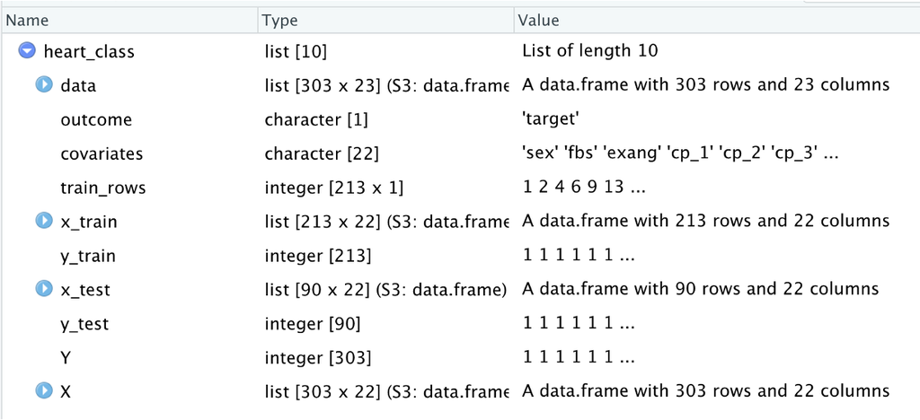

heart_class

```r
heart_class <- list(
  data = clean,
  outcome = "target" # Y variable column name
)

# View the list contents
names(heart_class)
```

```
## [1] "data"    "outcome"
```

```r
# Access part of the list with the dollar sign
head(heart_class$data)
```

```
##   sex fbs exang target cp_1 cp_2 cp_3 restecg_1 restecg_2 slope_1 slope_2 ca_1
## 1   1   1     0      1    0    0    1         0         0       0       0    0
## 2   1   0     0      1    0    1    0         1         0       0       0    0
## 3   0   0     0      1    1    0    0         0         0       0       1    0
## 4   1   0     0      1    1    0    0         1         0       0       1    0
## 5   0   0     1      1    0    0    0         1         0       0       1    0
## 6   1   0     0      1    0    0    0         1         0       1       0    0
##   ca_2 ca_3 ca_4 thal_1 thal_2 thal_3        age  trestbps      chol   thalach
## 1    0    0    0      1      0      0 0.11170213 0.2570922 0.4131206 0.2659574
## 2    0    0    0      0      1      0 0.06560284 0.2304965 0.4432624 0.3315603
## 3    0    0    0      0      1      0 0.07269504 0.2304965 0.3617021 0.3049645
## 4    0    0    0      0      1      0 0.09929078 0.2127660 0.4184397 0.3156028
## 5    0    0    0      0      1      0 0.10106383 0.2127660 0.6276596 0.2890071
## 6    0    0    0      1      0      0 0.10106383 0.2482270 0.3404255 0.2624113
##        oldpeak
## 1 0.0040780142
## 2 0.0062056738
## 3 0.0024822695
## 4 0.0014184397
## 5 0.0010638298
## 6 0.0007092199
```

```r
heart_class$outcome
```

```
## [1] "target"
```

## 8.1 Add covariates

```r
# setdiff is a handy base R function to define the covariates as all variables *except* the outcome
heart_class$covariates <- setdiff(names(heart_class$data), heart_class$outcome)

# The covariate names appear in the heart_class list!
names(heart_class)
```

```
## [1] "data"       "outcome"    "covariates"
```

```r
# Call the covariates with (notice that "target" is excluded)
heart_class$covariates
```

```
##  [1] "sex"       "fbs"       "exang"     "cp_1"      "cp_2"      "cp_3"
##  [7] "restecg_1" "restecg_2" "slope_1"   "slope_2"   "ca_1"      "ca_2"
## [13] "ca_3"      "ca_4"      "thal_1"    "thal_2"    "thal_3"    "age"
## [19] "trestbps"  "chol"      "thalach"   "oldpeak"
```

## 8.2 Add training rows

```r
# ?createDataPartition
set.seed(1)
training_rows <-
  caret::createDataPartition(heart_class$data[[heart_class$outcome]],
                             p = 0.70,
                             list = FALSE)

# assign the row indices
heart_class$train_rows <- training_rows

# We have added the training rows to our list
names(heart_class)
```

```
## [1] "data"       "outcome"    "covariates" "train_rows"
```

```r
head(heart_class$train_rows)
```

```
##      Resample1
## [1,]         1
## [2,]         2
## [3,]         4
## [4,]         5
## [5,]         6
## [6,]         9
```

## 8.3 Split data into training and test sets

```r
# use the train_rows indices to add the correct covariates and outcome to the training set
x_train <- heart_class$data[heart_class$train_rows, heart_class$covariates]
y_train <- heart_class$data[heart_class$train_rows, heart_class$outcome]

# note the use of the minus sign here
# this says to use the train_rows indices *not* assigned to the training set in the test set
x_test <- heart_class$data[-heart_class$train_rows, heart_class$covariates]
y_test <- heart_class$data[-heart_class$train_rows, heart_class$outcome]

# Mean and frequencies of training set
mean(heart_class$data[training_rows, "target"])
```

```
## [1] 0.5446009
```

```r
table(heart_class$data[training_rows, "target"])
```

```
##
##   0   1
##  97 116
```

```r
# Mean and frequencies of test set
mean(heart_class$data[-training_rows, "target"])
```

```
## [1] 0.5444444
```

```r
table(heart_class$data[-training_rows, "target"])
```

```
##
##  0  1
## 41 49
```

```r
# Add these variables to our list for safekeeping
heart_class$x_train <- x_train
heart_class$y_train <- y_train
heart_class$x_test <- x_test
heart_class$y_test <- y_test

# Also save X and Y for the ensemble, since we will use all of the data in the cross-validation process
heart_class$Y <- clean$target
heart_class$X <- clean[,-4]
names(heart_class)
```

```
##  [1] "data"       "outcome"    "covariates" "train_rows" "x_train"
##  [6] "y_train"    "x_test"     "y_test"     "Y"          "X"
```

### 8.3.1 Save the list `heart_class`

This way, you do not have to repeat all of these steps. You can just `load("data/preprocessed/heart_class.RData")`to load the data along with our preprocessed list!

```r
names(heart_class)
```

```
##  [1] "data"       "outcome"    "covariates" "train_rows" "x_train"
##  [6] "y_train"    "x_test"     "y_test"     "Y"          "X"
```

```r
save(clean, heart_class, # save the clean dataset as well
     file = "~/Desktop/Intro_ML_R/data/preprocessed/heart_class.RData")
```

# 9 Again, wipe your global environment clean

```r
# Then, load heart_class with the load function!
load("~/Desktop/Intro_ML_R/data/preprocessed/heart_class.RData")
names(heart_class)
```

```
##  [1] "data"       "outcome"    "covariates" "train_rows" "x_train"
##  [6] "y_train"    "x_test"     "y_test"     "Y"          "X"
```

```r
# or
# View(heart_class)

# or
# str(heart_class)
```

# 10 Fit single models

It can be good to fit a single model to prototype your machine learning task.

## 10.1 View available models

SuperLearner supports a wide variety of useful algorithms:

```r
listWrappers()
```

```
## All prediction algorithm wrappers in SuperLearner:
```

```
##  [1] "SL.bartMachine"      "SL.bayesglm"         "SL.biglasso"
##  [4] "SL.caret"            "SL.caret.rpart"      "SL.cforest"
##  [7] "SL.earth"            "SL.gam"              "SL.gbm"
## [10] "SL.glm"              "SL.glm.interaction"  "SL.glmnet"
## [13] "SL.ipredbagg"        "SL.kernelKnn"        "SL.knn"
## [16] "SL.ksvm"             "SL.lda"              "SL.leekasso"
## [19] "SL.lm"               "SL.loess"            "SL.logreg"
## [22] "SL.mean"             "SL.nnet"             "SL.nnls"
## [25] "SL.polymars"         "SL.qda"              "SL.randomForest"
## [28] "SL.ranger"           "SL.ridge"            "SL.rpart"
## [31] "SL.rpartPrune"       "SL.speedglm"         "SL.speedlm"
## [34] "SL.step"             "SL.step.forward"     "SL.step.interaction"
## [37] "SL.stepAIC"          "SL.svm"              "SL.template"
## [40] "SL.xgboost"
```

```
##
## All screening algorithm wrappers in SuperLearner:
```

```
## [1] "All"
## [1] "screen.corP"           "screen.corRank"        "screen.glmnet"
## [4] "screen.randomForest"   "screen.SIS"            "screen.template"
## [7] "screen.ttest"          "write.screen.template"
```

The following sections will fit using three common models: `single decision tree`, `random forest` and `lasso`, one at a time. See the links below for more information:

1. [Single decision tree](https://www.amazon.com/Classification-Regression-Wadsworth-Statistics-Probability/dp/0412048418)
2. [Random forest](https://link.springer.com/article/10.1023/A:1010933404324)
3. [Lasso](https://cran.r-project.org/web/packages/glmnet/vignettes/glmnet.pdf)

## 10.2 Decision tree

The decision tree algorithm can be useful because it is relatively simple to construct and interpret. It can work with categorical data directly, without the need for one-hot encoding.

Decision trees work by recursively partitioning, or dividing the feature space into smaller regions that contain less data. Splitting takes place at **nodes** and each directional split is called a **branch**. The top node is called the **root node** and seeks to find the most discriminating split, thus always putting the most optimal partition first. The tree stops partitioning when it fails to meet some hyperparameter condition.

For a regression tree, the predicted response for an observation is given by the mean response of the training observations that belong to the same **terminal node**. By contrast, for a classification tree, the model predicts that each observation belongs to the most commonly occurring class of training observations in the region to which it belongs.

Regression decision trees are used to predict a quantitative response, while classification trees, a qualitative one.

`rpart` R package provides a useful and simple way to grow classification and regression trees. See`?rpart` for additional information and `?rpart.control` for a list of tunings.

- [A tutorial for a step-by-step decision tree walkthrough](https://www.gormanalysis.com/blog/decision-trees-in-r-using-rpart/)
- [Constructing a decision tree](https://www.gormanalysis.com/blog/magic-behind-constructing-a-decision-tree/)
- [Stackoverflow thread about decision tree information gain.](https://stackoverflow.com/questions/4553947/decision-tree-on-information-gain)

Keep in mind that single decision trees are prone to overfitting and high variance in results on different training data.

Unhashtag the code below to reproduce the tree figure for the training data.

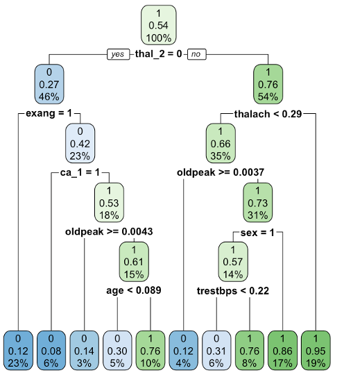

training set decision tree plot

```r
?rpart
?rpart.control
#install.packages("rpart.plot")
library(rpart.plot)
(dt_example_plot <- rpart(heart_class$y_train ~ .,
                           data = heart_class$x_train,
                           method = "class",
                           parms = list(split = "information")))
rpart.plot(dt_example_plot)
```

### 10.2.1 Train the model with SuperLearner

```r
set.seed(1)
dt <- SuperLearner(Y = heart_class$y_train,
                   X = heart_class$x_train,
                   family = binomial(),
                   SL.library = "SL.rpart")
dt
```

```
##
## Call:
## SuperLearner(Y = heart_class$y_train, X = heart_class$x_train, family = binomial(),
##     SL.library = "SL.rpart")
##
##
##                   Risk Coef
## SL.rpart_All 0.1743429    1
```

```r
# Accuracy
(dt_acc <- 1 - dt$cvRisk)
```

```
## SL.rpart_All
##    0.8256571
```

### 10.2.2 Compute decision tree test set AUC-ROC:

```r
# Predict on test set
dt_predictions = predict(dt, heart_class$x_test, onlySL = TRUE)
str(dt_predictions)
```

```
## List of 2
##  $ pred           : num [1:90, 1] 0.917 0.917 0.652 0.917 0.917 ...
##  $ library.predict: num [1:90, 1] 0.917 0.917 0.652 0.917 0.917 ...
```

```r
summary(dt_predictions$library.predict)
```

```
##        V1
##  Min.   :0.09091
##  1st Qu.:0.11111
##  Median :0.65217
##  Mean   :0.59937
##  3rd Qu.:0.91667
##  Max.   :0.91667
```

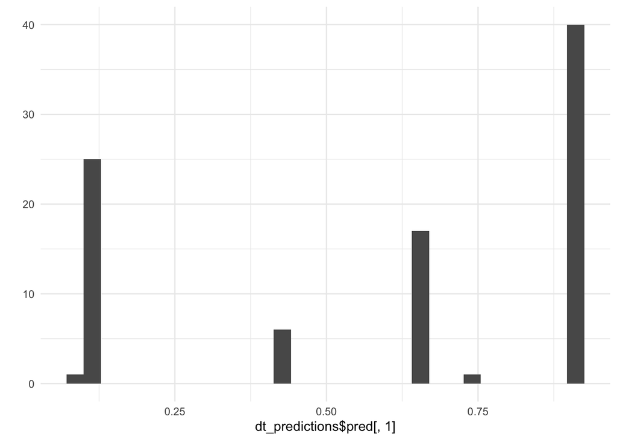

```r
# Visualize predicted probabilities
qplot(dt_predictions$pred[, 1]) + theme_minimal()
```

```r
# Compute AUC-ROC and save as a separate object
dt_rocr_score = ROCR::prediction(dt_predictions$pred, heart_class$y_test)
dt_auc_roc = ROCR::performance(dt_rocr_score, measure = "auc", x.measure = "cutoff")@y.values[[1]]

# AUC-ROC
dt_auc_roc
```

```
## [1] 0.7366849
```

Pros & Cons of Decision Trees:

- Trees are simple to explain and interpret visually.
- Trees can be applied to both regression and classification problems.
- Trees can handle qualitative predictors (like categorical variables) directly, without the need for converting to numeric variables.
- Trees do not have the same level of predictive accuracy as other regression or classification approaches.
- Trees are not very robust and small changes in the data can cause large changes in the final estimated tree.

The main disadvantage of decision trees is that they suffer from high variance. This means that splitting the training data into two parts at random, and fitting a decision tree to both halves, may generate results the are quite different.

## 10.3 Random forest

The random forest algorithm is an improvement over the single decision tree, and it works by constructing many decision trees at the time of training and averaging performance across the trees. It is therefore in itself an ensemble method.

This model is called **forest** because it grows multiple decision trees.

It is called **random** because instead of trying to place the most discriminating split as the root node, it selects a random sample of features to try at each split. This allows for good splits to be followed by bad splits, and vice versa, thus helping decorrelate the average performance estimator for a more statistically robust conclusion.

It is also **random** because it uses “bootstrapping” with replacement. This is when a new training set is generated by sampling from the main set, uniformly and with replacement: e.g. taking two-thirds of the dataset for each tree (this is called “bootstrap aggregating”, or “bagging”) and evaluating performance on the remaining one-third of the data (called the “out-of-bag” sample).

See `?ranger` for hyperparameter tuning options.

```r
?ranger
```

- [Read the ranger paper for explanations and examples.](https://arxiv.org/pdf/1508.04409.pdf).

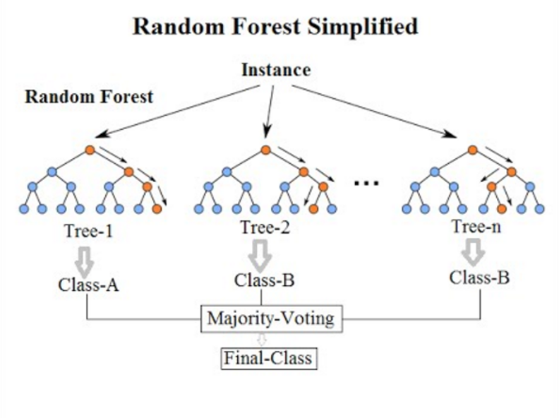

https://en.wikipedia.org/wiki/Random_forest

### 10.3.1 Train the model

```r
set.seed(1)
rf <- SuperLearner(Y = heart_class$y_train,
                   X = heart_class$x_train,
                   family = binomial(),
                   SL.library = "SL.ranger")
rf
```

```
##
## Call:
## SuperLearner(Y = heart_class$y_train, X = heart_class$x_train, family = binomial(),
##     SL.library = "SL.ranger")
##
##
##                    Risk Coef
## SL.ranger_All 0.1293912    1
```

```r
# Accuracy
(rf_acc <- 1 - rf$cvRisk)
```

```
## SL.ranger_All
##     0.8706088
```

### 10.3.2 Test set AUC-ROC:

```r
rf_predictions = predict(rf, heart_class$x_test, onlySL = TRUE)
str(rf_predictions)
```

```
## List of 2
##  $ pred           : num [1:90, 1] 0.97 0.762 0.566 0.901 0.941 ...
##  $ library.predict: num [1:90, 1] 0.97 0.762 0.566 0.901 0.941 ...
```

```r
summary(rf_predictions$library.predict)
```

```
##        V1
##  Min.   :0.008188
##  1st Qu.:0.337193
##  Median :0.619751
##  Mean   :0.592442
##  3rd Qu.:0.874289
##  Max.   :0.992931
```

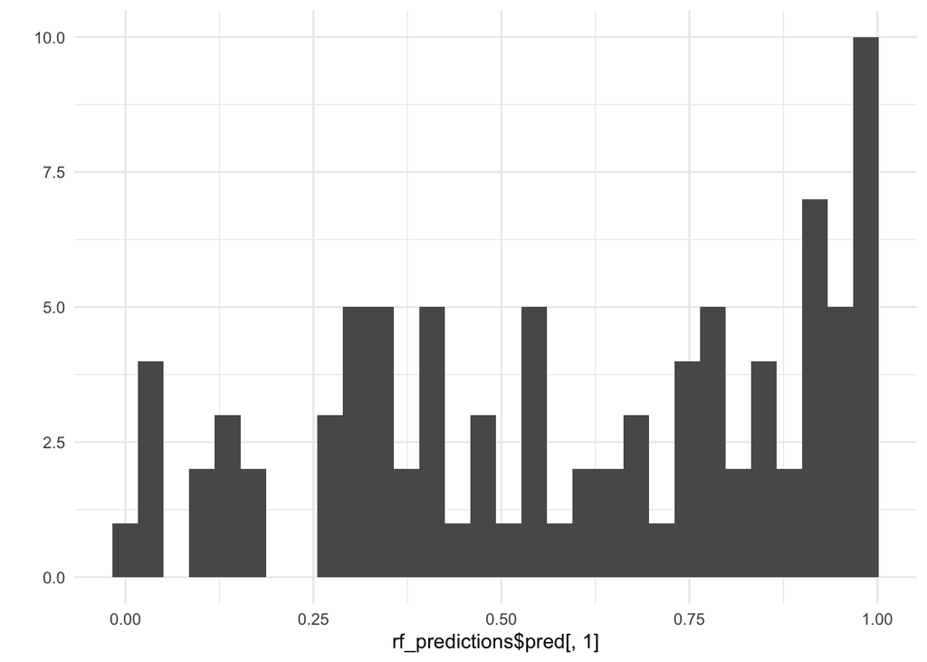

```r
# Visualize predicted probabilities
qplot(rf_predictions$pred[, 1]) + theme_minimal()
```

```r
# Compute AUC-ROC and save as a new object
rf_rocr_score = ROCR::prediction(rf_predictions$pred, heart_class$y_test)
rf_auc_roc = ROCR::performance(rf_rocr_score, measure = "auc", x.measure = "cutoff")@y.values[[1]]

# AUC-ROC
rf_auc_roc
```

```
## [1] 0.8596317
```

## 10.4 Lasso

In general, in situations where the relationship between the response and the predictors is close to linear, the `Least Squares Regresson` will have low bias but may have high variance. This means that a small change in the training data can cause a large change in the least squares coefficient estimates. In particular, when the number of variables is almost as large as the number of observations the least squares estimates will be extremely variable. Whereas `Ridge Regression` can still perform well by trading off a small increase in bias for a large decrease in variance.

The “penalizing”, or addition of a “penalty term”, in essence improves the generalization capability of the model.

In `Ridge Regression`, the error = RSS + (λ * β^2). The latter is the “penalty term” defined by the β coefficient (or the slope of the line) squared, multiplied by the “regularization” or tuning parameter λ, to be determined separately.

The `Lasso` is a form of penalized regression and classification that “shrinks” the β coefficient to zero and identifies features that are not related to the outcome variable. This is achieved by taking the absolute value of the β coefficient, rather than squaring it, so the error = RSS + |λ * β|.

To summarize:

- Least Squares Regression: error = RSS
- Ridge Regression: error = RSS + (λ * β^2)
- Lasso Regression: error = RSS + |λ * β|

`Lasso Regression` can help reduce overfitting, but unlike `Ridge Regression` it can reduce the slope to exactly zero. This can be used for feature selection, where every non-zero value is selected to be used in the model, and variables or paramaters not related to the response variable can be identified and eliminated.

From this, the “one standard error rule” can be applied, which allows selecting a higher λ value (the regularization parameter) within one standard error of the minimum value, and sacrifice a little error for a model that contains less variables but is ostensibly easier to interpret.

`Lasso` performs best when the number of observations is low and the number of features is high. It heavily relies on parameter λ, which is the controlling factor in shrinkage (where every non-zero value is selected to be used in the model). The larger λ becomes, then the more coefficients are forced to be zero.

View the help files with `?glmnet` and `?cv.glmnet` to learn more.

```r
?glmnet
?cv.glmnet
```

- [Remember to read An Introduction to glmnet](https://cran.r-project.org/web/packages/glmnet/vignettes/glmnet.pdf)

### 10.4.1 Lasso - train the model with SuperLearner

```r
set.seed(1)
la <- SuperLearner(Y = heart_class$y_train,
                   X = heart_class$x_train,
                   family = binomial(),
                   SL.library = "SL.glmnet")
la
```

```
##
## Call:
## SuperLearner(Y = heart_class$y_train, X = heart_class$x_train, family = binomial(),
##     SL.library = "SL.glmnet")
##
##
##                    Risk Coef
## SL.glmnet_All 0.1178595    1
```

```r
# Accuracy
(la_risk <- 1-la$cvRisk)
```

```
## SL.glmnet_All
##     0.8821405
```

### 10.4.2 Lasso test set AUC-ROC:

```r
la_predictions = predict(la, heart_class$x_test, onlySL = TRUE)
str(la_predictions)
```

```
## List of 2
##  $ pred           : num [1:90, 1] 0.916 0.74 0.749 0.859 0.965 ...
##  $ library.predict: num [1:90, 1] 0.916 0.74 0.749 0.859 0.965 ...
```

```r
summary(la_predictions$library.predict)
```

```
##        V1
##  Min.   :0.008801
##  1st Qu.:0.299391
##  Median :0.633026
##  Mean   :0.580456
##  3rd Qu.:0.903609
##  Max.   :0.988807
```

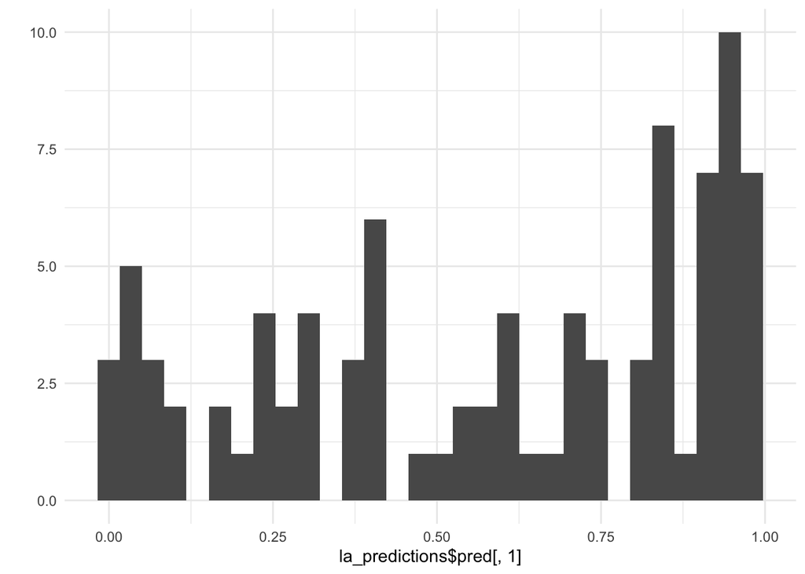

```r
# Visualize predicted probabilities
qplot(la_predictions$pred[, 1]) + theme_minimal()
```

```r
# Compute AUC-ROC and save as a new object
la_rocr_score = ROCR::prediction(la_predictions$pred, heart_class$y_test)
la_auc_roc = ROCR::performance(la_rocr_score, measure = "auc", x.measure = "cutoff")@y.values[[1]]

# AUC-ROC
la_auc_roc
```

```
## [1] 0.8939771
```

### 10.4.3 Bonus: cross-validated lasso with `cv.glmnet`

```r
set.seed(1)
lasso <- cv.glmnet(x = as.matrix(heart_class$X),
                   y = heart_class$Y,
                   family = "binomial",
                   alpha = 1)
lasso
```

```
##
## Call:  cv.glmnet(x = as.matrix(heart_class$X), y = heart_class$Y, family = "binomial",      alpha = 1)
##
## Measure: Binomial Deviance
##
##      Lambda Index Measure      SE Nonzero
## min 0.01012    36  0.7631 0.06686      18
## 1se 0.03392    23  0.8285 0.04659      15
```

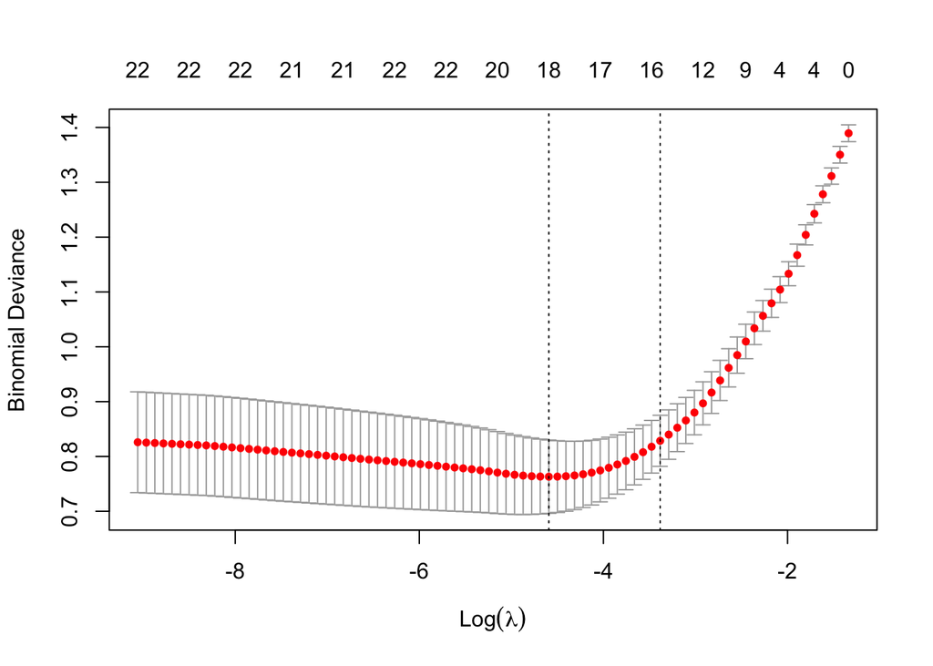

```r
# View path plot
plot(lasso)
```

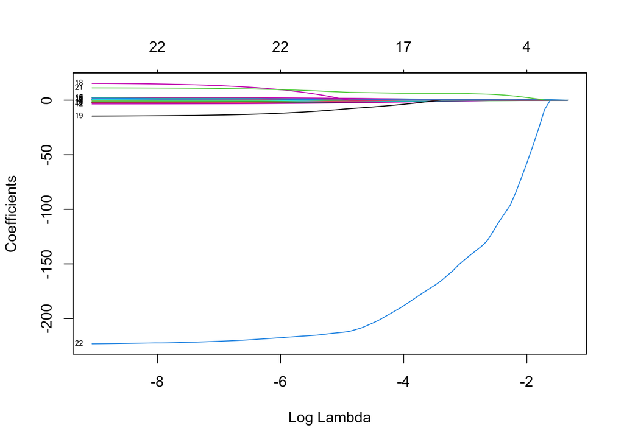

```r
# View coefficients
plot(lasso$glmnet.fit, xvar = "lambda", label = TRUE)
```

```r
# Show coefficients for 1se model
(coef_min = coef(lasso, s = "lambda.1se"))
```

```
## 23 x 1 sparse Matrix of class "dgCMatrix"
##                       s1
## (Intercept)   -0.5608427
## sex           -0.4290884
## fbs            .
## exang         -0.6548822
## cp_1           0.1442183
## cp_2           0.6982435
## cp_3           0.3563876
## restecg_1      0.1032213
## restecg_2      .
## slope_1       -0.3557496
## slope_2        0.1325356
## ca_1          -0.8761617
## ca_2          -1.2264879
## ca_3          -0.7966503
## ca_4           .
## thal_1         .
## thal_2         0.6554511
## thal_3        -0.5795217
## age            .
## trestbps       .
## chol           .
## thalach        6.1897480
## oldpeak     -165.2682983
```

# 11 Ensemble

In this example, three algorithms have been compared: the decision tree performed relatively poorly compared to the random forest and lasso. So, how do we know which algorithm to choose? Let’s fit an ensemble with two more algorithms:

4. [xgboost](https://www.google.com/search?client=firefox-b-1-d&q=short+introduction+to+boosting+freund)
5. [The mean of Y](https://biostats.bepress.com/ucbbiostat/paper266/)

## 11.1 Summary of algorithm definitions

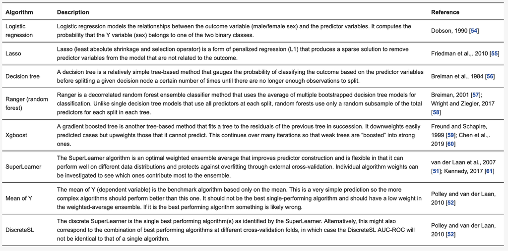

https://www.mdpi.com/2227-7080/9/2/23/htm

## 11.2 Train the ensemble of models

```r
set.seed(1)
system.time({
cv_sl <- CV.SuperLearner(Y = heart_class$Y,  # heart disease yes/no
                         X = heart_class$X,  # excluding the "target" variable
                         family = binomial(),
                         # For your own research, 5, 10, or 20 are good options
                         cvControl = list(V = 5),
                         innerCvControl = list(list(V = 5)),
                         verbose = FALSE,
                         method = "method.NNLS",
                         SL.library = c("SL.rpart",   # decision tree
                                        "SL.ranger",  # random forest
                                        "SL.glmnet",  # lasso
                                        "SL.xgboost", # boosted trees
                                        "SL.mean"))   # Y mean
})
```

```
##    user  system elapsed
##   9.054   0.205   9.034
```

## 11.3 Explore the output

```r
# View the function call
cv_sl
```

```
##
## Call:
## CV.SuperLearner(Y = heart_class$Y, X = heart_class$X, family = binomial(),
##     SL.library = c("SL.rpart", "SL.ranger", "SL.glmnet", "SL.xgboost", "SL.mean"),
##     method = "method.NNLS", verbose = FALSE, cvControl = list(V = 5), innerCvControl = list(list(V = 5)))
##
##
##
## Cross-validated predictions from the SuperLearner:  SL.predict
##
## Cross-validated predictions from the discrete super learner (cross-validation selector):  discreteSL.predict
##
## Which library algorithm was the discrete super learner:  whichDiscreteSL
##
## Cross-validated prediction for all algorithms in the library:  library.predict
```

```r
# View the risk table for:
# 1. The individual algorithms
# 2. The discrete winner
# 3. The SuperLearner ensemble
summary(cv_sl)
```

```
##
## Call:
## CV.SuperLearner(Y = heart_class$Y, X = heart_class$X, family = binomial(),
##     SL.library = c("SL.rpart", "SL.ranger", "SL.glmnet", "SL.xgboost", "SL.mean"),
##     method = "method.NNLS", verbose = FALSE, cvControl = list(V = 5), innerCvControl = list(list(V = 5)))
##
##
## Risk is based on: Mean Squared Error
##
## All risk estimates are based on V =  5
##
##       Algorithm     Ave        se      Min     Max
##   Super Learner 0.11722 0.0113943 0.088134 0.15460
##     Discrete SL 0.11607 0.0116867 0.084784 0.15543
##    SL.rpart_All 0.18315 0.0167049 0.142558 0.23328
##   SL.ranger_All 0.13734 0.0105342 0.122008 0.16847
##   SL.glmnet_All 0.11607 0.0116867 0.084784 0.15543
##  SL.xgboost_All 0.14758 0.0139655 0.110688 0.19415
##     SL.mean_All 0.24944 0.0026639 0.244474 0.25555
```

```r
# View the discrete winner
table(simplify2array(cv_sl$whichDiscreteSL))
```

```
##
## SL.glmnet_All
##             5
```

```r
# View the AUC-ROC table for:
# 1. The individual algorithms
# 2. The discrete winner
# 3. The SuperLearner ensemble
ck37r::auc_table(cv_sl)
```

```
##                      auc         se  ci_lower  ci_upper      p-value
## SL.mean_All    0.5000000 0.05767758 0.3869540 0.6130460 4.666398e-13
## SL.rpart_All   0.7753934 0.03589421 0.7050420 0.8457447 7.213063e-05
## SL.xgboost_All 0.8657012 0.02082595 0.8248831 0.9065194 1.340076e-02
## SL.ranger_All  0.8851278 0.01857296 0.8487255 0.9215302 7.535160e-02
## SuperLearner   0.9100506 0.01667676 0.8773648 0.9427365 4.577962e-01
## SL.glmnet_All  0.9118182 0.01638189 0.8797102 0.9439261 5.000000e-01
## DiscreteSL     0.9118182 0.01638189 0.8797102 0.9439261 5.000000e-01
```

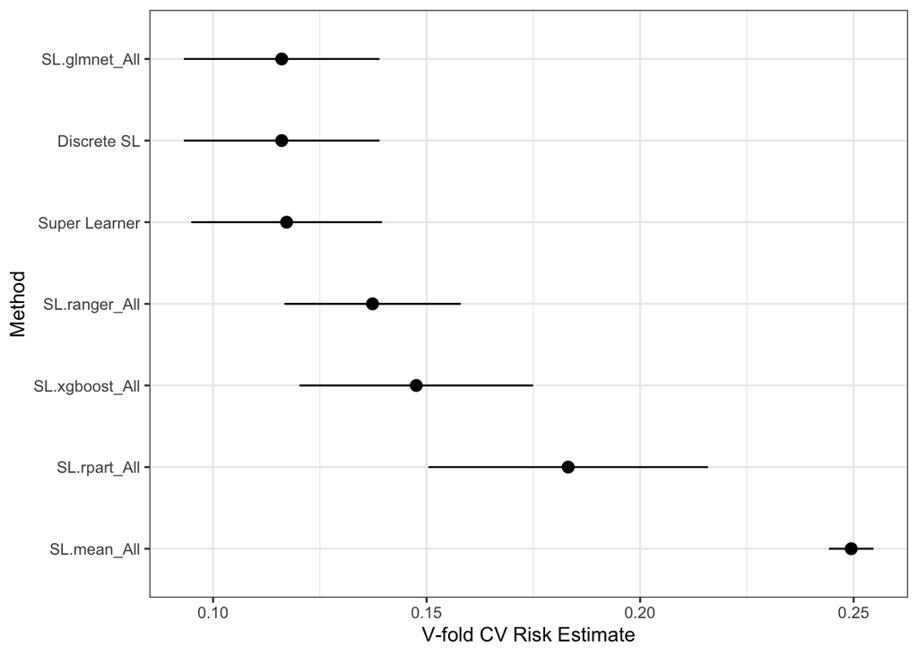

```r
# Visualize the cross-validated risk
plot.CV.SuperLearner(cv_sl) + theme_bw()
```

```r
# Print the weights table
cvsl_weights(cv_sl)
```

```
##   # Learner    Mean      SD     Min     Max
## 1 1  glmnet 0.84904 0.08951 0.77596 1.00000
## 2 2  ranger 0.13957 0.08266 0.00000 0.22044
## 3 3   rpart 0.00811 0.01620 0.00000 0.03695
## 4 4 xgboost 0.00328 0.00733 0.00000 0.01638
## 5 5    mean 0.00000 0.00000 0.00000 0.00000
```

```r
# Compute ensemble AUC-ROC
ck37r::cvsl_auc(cv_sl)
```

```
## $cvAUC
## [1] 0.9100506
##
## $se
## [1] 0.01667676
##
## $ci
## [1] 0.8773648 0.9427365
##
## $confidence
## [1] 0.95
```

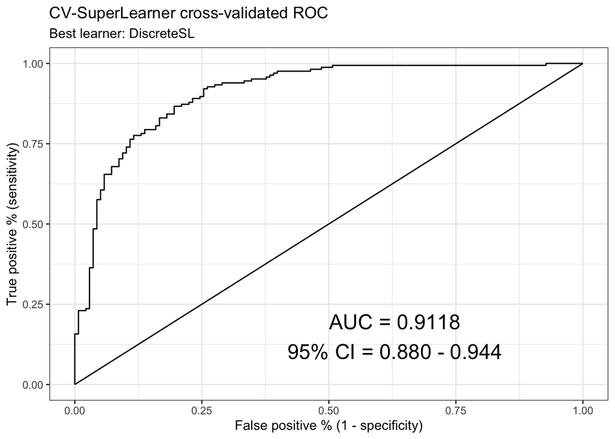

```r
# Plot AUC-ROC curve
ck37r::plot_roc(cv_sl)
```

```r
# View rough estimates of variable importance
set.seed(1)
var_importance <- ck37r::vim_corr(covariates = heart_class$covariates,
                                  outcome = heart_class$outcome,
                                  data = clean,
                                  bootse = FALSE,
                                  verbose = TRUE)
var_importance
```

```
##     rank  variable        corr type      p_value  p_value_fdr     avg_con
## 015    1    thal_2  0.52733355 corr 4.356225e-23 9.583695e-22 0.260869565
## 016    2    thal_3 -0.48611215 corr 2.241269e-19 2.465396e-18 0.644927536
## 02     3     exang -0.43675708 corr 1.520814e-15 1.115263e-14 0.550724638
## 021    4   oldpeak -0.43069600 corr 4.085346e-15 2.246941e-14 0.002811183
## 020    5   thalach  0.42174093 corr 1.697338e-14 7.468286e-14 0.246633775
## 09     6   slope_2  0.39406637 corr 1.068761e-12 3.918791e-12 0.253623188
## 08     7   slope_1 -0.36205330 corr 8.142433e-11 2.559051e-10 0.659420290
## 04     8      cp_2  0.31674216 corr 1.735460e-08 4.772515e-08 0.130434783
## 0      9       sex -0.28093658 corr 6.678692e-07 1.632569e-06 0.826086957
## 011   10      ca_2 -0.27399787 corr 1.280668e-06 2.817470e-06 0.224637681
## 03    11      cp_1  0.24587910 corr 1.498284e-05 2.996568e-05 0.065217391
## 010   12      ca_1 -0.23241224 corr 4.409069e-05 8.083294e-05 0.318840580
## 017   13       age -0.22543872 corr 7.524801e-05 1.273428e-04 0.100357180
## 012   14      ca_3 -0.21061527 corr 2.220536e-04 3.489414e-04 0.123188406
```

[output cut: 31 more lines]

# 12 Challenge

## 12.1 Customize model hyperparameters and refit the ensemble

See Chapter 9 and Chapter 10 in the [Guide to SuperLearner](https://cran.r-project.org/web/packages/SuperLearner/vignettes/Guide-to-SuperLearner.html) for how to customize model hyperparameters and test the same algorithms with multiple hyperparameter settings. Refit the ensemble with a few new, tuned algorithms and compare to the existing algorithms contained within the `SL.library` parameter, inside of `CV.SuperLearner` above (“SL.rpart”, “SL.ranger”, “SL.glmnet”, “SL.xgboost”, “SL.mean”).

What changed, and how were you able to optimize performance?

How did you find out which hyperparameters to tune?

> HINT: type `?rpart`, `?ranger`, etc.

Also, consider the following points for improving performance: - Change nominal factors to ordinal type when appropriate  
- Explore other ways to scale numeric variables  
- Include other algorithms  
- Utilize other/more performance metrics  
- [Read more](https://machinelearningmastery.com/machine-learning-performance-improvement-cheat-sheet/)

# 13 Other tutorials

caret: https://topepo.github.io/caret/

tidymodels: https://www.tidymodels.org/

mikropml: http://www.schlosslab.org/mikropml/articles/paper.html